# Machine Learning Writeup

Michael

September 23, 2015

# Introduction

This is my writeup for the Practical Machine Learning Course Project. The project is to generate a model that can distinguish the correct performance of a dumbbell curve from four common errors. The data is from research done by Velloso, Bulling, Gellersen, Ugulino, and Fuks for their paper: “[Qualitative Activity Recognition of Weight Lifting Exercises](http://groupware.les.inf.puc-rio.br/work.jsf?p1=11201)”. More information can be found at their website http://groupware.les.inf.puc-rio.br/har.

This report assumes that two files (pml-training.csv and pml-testing.csv) provided by the course instructors are available in the working directory although pml-testing won’t be read until model training is complete.

```r
training <- read.csv('pml-training.csv')
```

The data has several fields with large numbers of missing values as seen below.

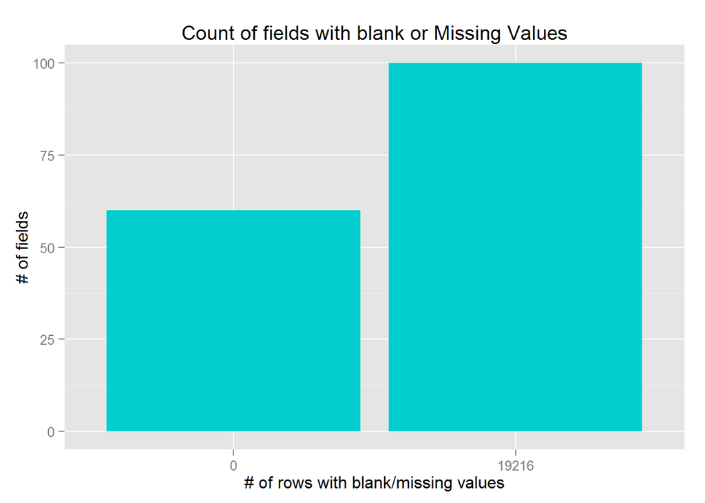

In addition to the columns with 19216 of 19622 rows blank or missing; the first 7 columns involve timing of the measurements, rather than anything related to the performance of the exercise. I’ll remove those fields, as well as any remaining highly correlated fields to avoid their use in my model.

Because I’m interested in a model that’s accurate, rather than one that’s interpretable, I’m going to use random forests to build the model. However, it would take prohibitively long to build the model using all the remaining 46 fields so I’m going to run models on sampled partitions to identify which fields are most interesting.

```
## rf variable importance
##
##   only 20 most important variables shown (out of 45)
##
##                      Overall
## pitch_forearm         100.00
## yaw_belt               95.52
## magnet_dumbbell_y      87.71
## magnet_dumbbell_z      72.02
## roll_forearm           65.80
## pitch_belt             54.83
## magnet_belt_z          41.75
## gyros_belt_z           33.90
## accel_dumbbell_y       33.63
## magnet_belt_y          31.65
## roll_dumbbell          30.36
## magnet_dumbbell_x      27.72
## accel_forearm_x        17.39
## yaw_dumbbell           16.58
## accel_forearm_z        15.82
## total_accel_dumbbell   14.43
## magnet_belt_x          14.18
## magnet_forearm_z       13.44
## accel_dumbbell_z       12.57
## magnet_forearm_y       12.40
```

```
## rf variable importance
##
##   only 20 most important variables shown (out of 45)
##
##                      Overall
## pitch_forearm         100.00
## magnet_belt_y          66.11
## yaw_belt               65.04
## magnet_dumbbell_y      59.05
## magnet_dumbbell_z      58.50
## magnet_belt_z          44.57
## pitch_belt             43.28
## roll_dumbbell          37.26
## accel_dumbbell_y       33.13
## roll_forearm           31.11
## magnet_dumbbell_x      30.63
## gyros_belt_z           24.11
## accel_forearm_x        22.44
## magnet_forearm_z       18.17
## total_accel_dumbbell   16.13
## magnet_arm_x           15.99
## accel_dumbbell_z       15.36
## magnet_belt_x          14.74
## yaw_dumbbell           14.16
## roll_arm               14.14
```

The two models agree on very closely on the most important fields, I’ll take the fields that appear in the top 10 of either sample and use them to build the final model. Train uses cross validation to estimate OOB error, but I’ll train it on 80% of the training data and reserve the other 20% as a cross-validation test.

```r
trainSet <- createDataPartition(training$classe, p=0.8, list=FALSE)

finalTrain = training[trainSet,]
prelimTest = training[-trainSet,]

finalModel <- train(classe ~ pitch_forearm + yaw_belt + magnet_dumbbell_y + magnet_dumbbell_z + roll_forearm + pitch_belt + magnet_belt_z + gyros_belt_z + accel_dumbbell_y + magnet_belt_y + roll_dumbbell, data=finalTrain, method="rf")

finalModel$finalModel
```

```
##
## Call:
##  randomForest(x = x, y = y, mtry = param$mtry)
##                Type of random forest: classification
##                      Number of trees: 500
## No. of variables tried at each split: 6
##
##         OOB estimate of  error rate: 1.48%
## Confusion matrix:
##      A    B    C    D    E class.error
## A 4427   14   17    4    2 0.008288530
## B   22 2955   44   16    1 0.027320606
## C    6   25 2677   29    1 0.022279036
## D    0    3   26 2539    5 0.013214147
## E    0    4    5    9 2868 0.006237006
```

That provides a good OOB accuracy estimate, and when applied to the data I held out for testing.

```
## Confusion Matrix and Statistics
##
##           Reference
## Prediction    A    B    C    D    E
##          A 1108    4    0    0    0
##          B    3  738   11    0    0
##          C    5   11  668    6    0
##          D    0    5    5  636    0
##          E    0    1    0    1  721
##
## Overall Statistics
##
##                Accuracy : 0.9867
##                  95% CI : (0.9827, 0.9901)
##     No Information Rate : 0.2845
##     P-Value [Acc > NIR] : < 2.2e-16
##
##                   Kappa : 0.9832
##  Mcnemar's Test P-Value : NA
##
## Statistics by Class:
##
##                      Class: A Class: B Class: C Class: D Class: E
## Sensitivity            0.9928   0.9723   0.9766   0.9891   1.0000
## Specificity            0.9986   0.9956   0.9932   0.9970   0.9994
## Pos Pred Value         0.9964   0.9814   0.9681   0.9845   0.9972
## Neg Pred Value         0.9972   0.9934   0.9951   0.9979   1.0000
## Prevalence             0.2845   0.1935   0.1744   0.1639   0.1838
## Detection Rate         0.2824   0.1881   0.1703   0.1621   0.1838
## Detection Prevalence   0.2835   0.1917   0.1759   0.1647   0.1843
## Balanced Accuracy      0.9957   0.9840   0.9849   0.9930   0.9997
```